# The adult mosquito model RMG

A Behavioral State Model

March 18, 2024

Most of the models developed to model malaria parasite infections in mosquitoes look at the *infection states:* uninfected; infected; or infected and infectious. A few models have been developed that track also track *parity.* A different class of models tracks the behavioral / physiological state of mosquitoes, so we call them *behavioral state models.* A model with both *infection states* and *behavioral states* was first published by Le Menach, *et al.* (2005)[^1].

## The Model

This is a patch-based model with $p$ patches, and we assume that all the parameters, variables, and terms are of length $p$ except for $\Omega_b$ and $\Omega_q$, which are $p \times p$ matrices.

### Variables

- $U_b$ - uninfected, blood feeding mosquitoes
- $U_q$ - uninfected, egg laying mosquitoes
- $Y_b$ - infected but not infective, blood feeding mosquitoes
- $Y_q$ - infected but not infective, egg laying mosquitoes
- $Z_b$ - infective, blood feeding mosquitoes
- $Z_q$ - infective, egg laying mosquitoes

### Terms

Two terms are passed from another component of the model.

- $\Lambda$ - the emergence rate of adult mosquitoes from aquatic habitats in each patch
- $\kappa$ - the net infectiousness of humans, the probability a mosquito becomes infected after blood feeding on a human

### Parameters

**Bionomics** - Each one of the following parameters can take on a unique value in each patch.

- $f$ - the blood feeding rate
- $q$ - the human blood feeding fraction
- $\nu$ - the egg laying rate
- $g$ - the mosquito death rate, per mosquito
- $\varphi$ - the rate that infected mosquitoes become infective, the inverse of the EIP
- $\sigma_b$ - the patch emigration rate for blood-feeding mosquitoes
- $\sigma_q$ - the patch emigration rate for egg-laying mosquitoes

**Dipsersal Matrices** - Each one of the following parameters can take on a unique value in each patch.

- ${\cal K}_b$ - the dispersal matrix for blood-feeding mosquitoes, which has the form:
  $${\cal K} = \left[
  \begin{array}{ccccl}
  0 & k_{1,2} & k_{1,3} & \ldots & k_{1,p} \\
  k_{2,1} & 0 & k_{2,3} & \ldots & k_{2,p} \\
  k_{3,1} & k_{3,2} & 0 & \ldots & k_{3,p} \\
  \vdots& \vdots &\vdots & \ddots & k_{p-1, p} \\
  k_{p,1} & k_{p,2} & k_{p,3} & \ldots & 0 \\
  \end{array}
  \right].$$
  The diagonal elements are all $0$, and other elements, $k_{i,j} \in {\cal K}$, are the fraction of blood feeding mosquitoes leaving patch $j$ that end up in patch $i$; the notation should be read as $i \leftarrow j$, or *to $i$ from $j$*. Notably, the form of $\cal K$ is constrained such that
  $$\sum_i k_{i,j} = 1.$$
- ${\cal K}_q$ - the dispersal matrix for egg-laying mosquitoes, which has the same form as ${\cal K}_b$

**The Demographic Matrices**

- $\Omega_b$ - the demographic matrix for blood feeding mosquitoes; letting $I$ denote the identity matrix,
  $$\Omega_b = \mbox{diag}\left(g\right) -
  \mbox{diag}\left(\sigma_b\right) \left(I - \cal K_b
  \right)$$
- $\Omega_q$ - the demographic matrix for egg laying mosquitoes; which has the same form as $\Omega_b$.

### Dynamics

The following equations track adult mosquito behavioral and infection dynamics. A key assumption is that a fraction $q\kappa$ of blood feeding, uninfected mosquitoes become infected, thus transition from $U_b$ to $Y_g.$

$$\begin{array}{rl}
\dfrac{dU_b}{dt} &= \Lambda + \nu U_g - f U_b - \Omega_b \cdot U_b
\\
\dfrac{dU_g}{dt} &= f (1- q \kappa) U_b - \nu U_g - \Omega_g \cdot
U_g \\
\dfrac{dY_b}{dt} &= \nu Y_g + \phi Y_g - (f+\varphi) Y_g - \Omega_b
\cdot Y_b \\
\dfrac{dY_g}{dt} &= f q \kappa U_b + f Y_b - (\nu + \varphi) Y_g -
\Omega_g \cdot Y_g \\
\dfrac{dZ_b}{dt} &= \varphi Y_b + \nu Z_g - f Z - \Omega_b \cdot Z_b
\\
\dfrac{dZ_g}{dt} &= \varphi Y_g + f Z - \nu Z - \Omega_q \cdot Z_q
\end{array}$$

## Implementation

The `xde_setup()` utilities allow the user to pass a single version of the dispersal matrix $\cal K.$ During `xde_setup()`, `Omega_b` and `Omega_q` are identical.

```r
model <- xde_setup(MYZname="RMG", Lname="trace", Xname = "trace", nPatches=3)
```

```r
model <- xde_solve(model)
```

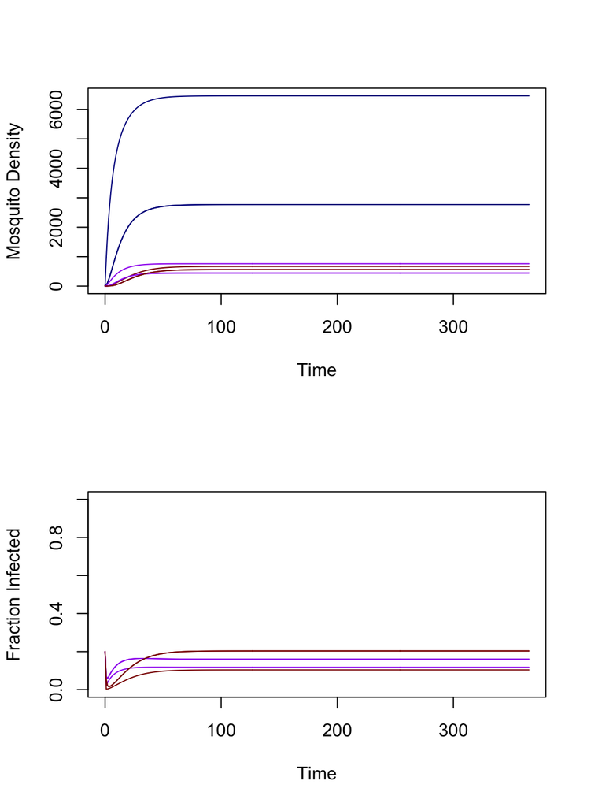

```r
par(mfrow = c(2,1))
xde_plot_M(model)
xde_plot_YZ(model, add_axes = F)
xde_plot_YZ_fracs(model)
```

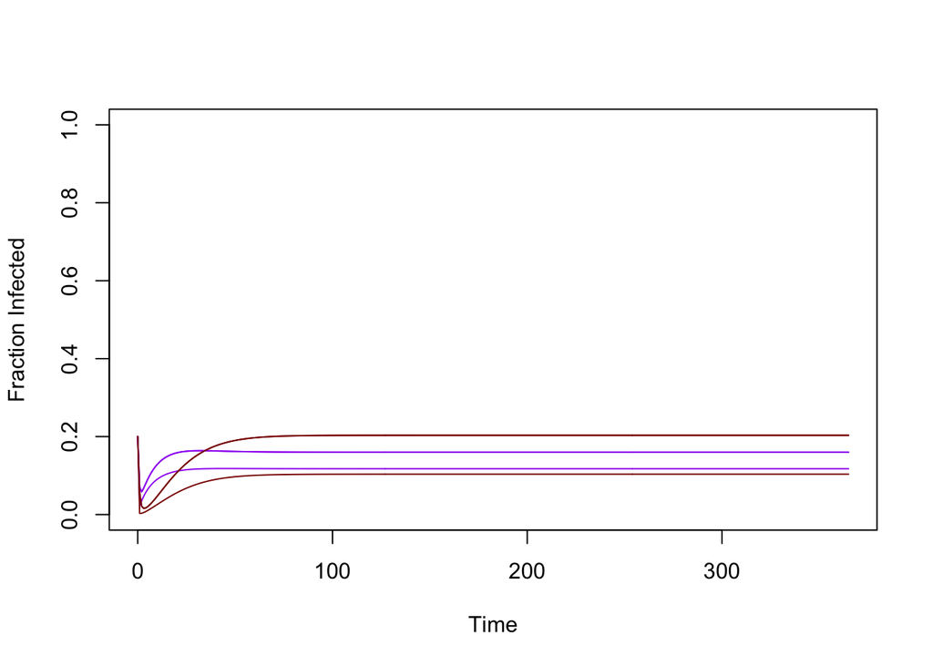

```r
xde_plot_YZ_fracs(model)
```

[^1]: Menach AL, *et al.* The unexpected importance of mosquito oviposition behaviour for malaria: non-productive larval habitats can be sources for malaria transmission. Malar J 4, 23 (2005). https://doi.org/10.1186/1475-2875-4-23